# Practical Machine Learning - Project #1

Mindy Montgomery

September 25, 2015

# Overview

Using the Weight Lifting Exercise Dataset, we will develop a model that attempts to predict how well a given participant performed a weightlifting exercise. Full details of the dataset can be found at http://groupware.les.inf.puc-rio.br/har. Full citation for the dataset and associated information can be found at the end of this document.

Using the data set, we will develop a model that predicts “classe”, based on selected features in the data. As described in the source website, the decriptions of the “classe” factors are as follows:

A - exercise performed exactly according to the specification B - error - throwing elbows to the front C - error - lifting the dumbbell only halfway D - error - lowering the dumbbell only halfway E - error - throwing the hips to the front

# Preliminary Data Investigation

In looking at the data set and reading the documentation associated with it, we see there are a large number of variables and data points included. Key to developing a good model will be selecting the correct number of these variables (there are 160 to choose from) that will reasonably predict which exercises in the test set were done correctly.

```
## [1] 19622   160
```

```
##     na_count
##  Min.   :    0
##  1st Qu.:    0
##  Median :19216
##  Mean   :12010
##  3rd Qu.:19216
##  Max.   :19216
```

```
## [1] 19622    60
```

Initially, I tried to subset out a bunch of the variables to only use a few in an attempt to avoid overfitting and to attempt to replicate what was found in the associated paper. Unfortunetaly, I did something wrong in my subsetting of the data and got this error: “Error: variables ‘avg_roll_belt’, ‘max_roll_belt’, ‘var_accel_arm’, ‘var_accel_forearm’, ‘amplitude_roll_arm’, ‘amplitude_roll_forearm’, ‘var_accel_dumbbell’, ‘var_roll_dumbbell’, ‘amplitude_roll_dumbbell’ were specified with different types from the fit”. I’m including my code at the end of the document as an appendix. This time, I’m going to examine a subset of variables (with the NAs removed) and the time and user-name based variables removed. After multiple attempts to run the random forest and GBM models with the data set of 53, 27, and 14 variables (all data, dumbbell and magnenometer data, and just dumbbell data, respectively), I took another look at the data set and observed that there were totals for some of the variables, which will considerably reduce the data set. Since there are not totals for all of the variables, I will use the totals and the “roll” variables to build the model, which reduces the number of predictors down to 8.

```r
  library(caret)
  library(kernlab)
  inTrain <- createDataPartition(y=dataForModel$classe, p = .6, list = FALSE)
  training <- dataForModel[inTrain,]
  testing <- dataForModel[-inTrain,]
  dim(training)
```

```
## [1] 11776     9
```

```r
  dim(testing)
```

```
## [1] 7846    9
```

Let’s look at a couple of the predictors graphically to see if we can fruther eliminate variables or find variables which have a large correlation with the exercise error classification.

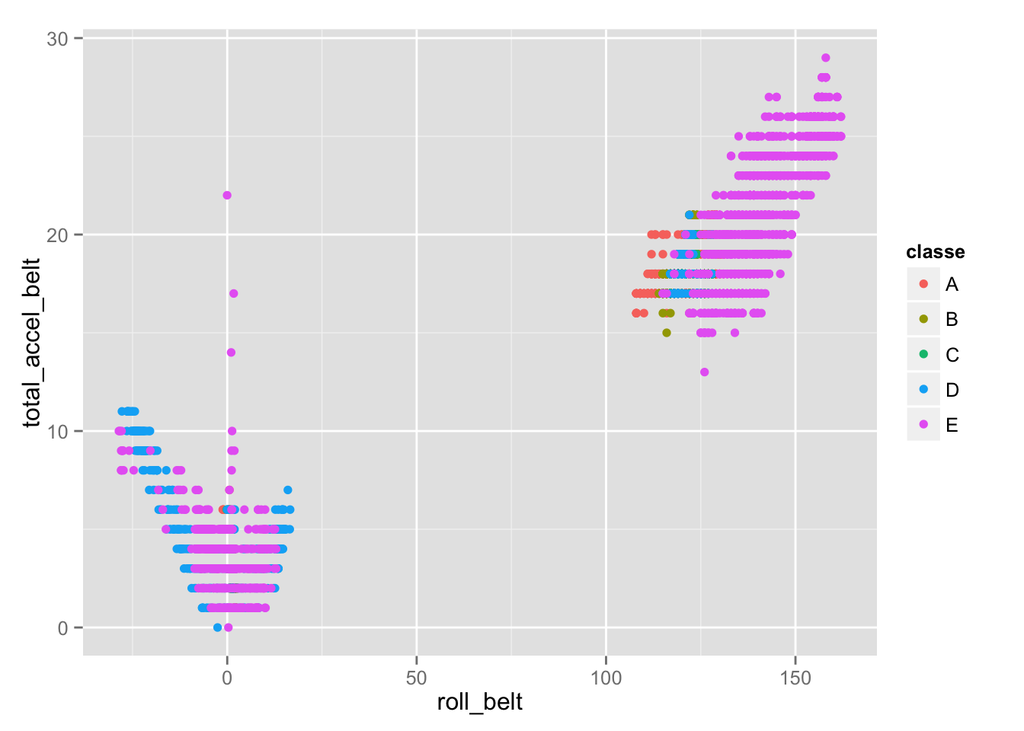

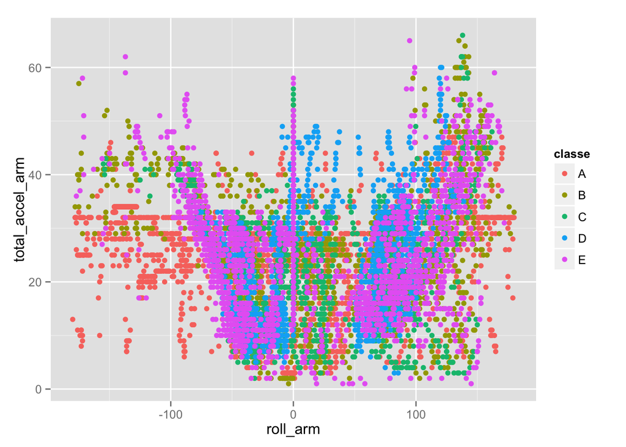

# Training the Model

```r
  library(randomForest)
  set.seed(125)
  randomForestModel <- randomForest(classe ~., data = dataForModel, ntree = 500, keep.forest = TRUE, importance = TRUE)
  print(randomForestModel)
```

```
##
## Call:
##  randomForest(formula = classe ~ ., data = dataForModel, ntree = 500,      keep.forest = TRUE, importance = TRUE)
##                Type of random forest: classification
##                      Number of trees: 500
## No. of variables tried at each split: 2
##
##         OOB estimate of  error rate: 3.6%
## Confusion matrix:
##      A    B    C    D    E class.error
## A 5463   25   49   34    9  0.02096774
## B   51 3580  112   42   12  0.05715038
## C   29   53 3272   60    8  0.04383402
## D   24   22  103 3059    8  0.04881841
## E    2   14   20   29 3542  0.01802052
```

As we can see from the output of the Random Forest model, we have an accuracy of approximately 96%, based on all of the predictors.

# Testing the Model

We will apply our Random Forest model to our test set of data.

```r
  RFPrediction = predict(randomForestModel, testing)
  summary(RFPrediction)
```

```
##    A    B    C    D    E
## 2232 1518 1368 1286 1442
```

# Running against the Test Data

Now we’re ready to run one of our models against the provided test data and then sumbit our results to the course website.

```r
  ## Read in the test data set
  dataToPredict <- read.csv("pml-testing.csv")
  ## Run the prediction algorithm against the provided test set
  predictedData <- predict(randomForestModel, dataToPredict)
```

# Out of Sample Error

```r
  dim(testing)
```

```
## [1] 7846    9
```

```r
  OOSErrorAcc = sum(RFPrediction == testing$classe)/length(RFPrediction)
  print(OOSErrorAcc)
```

```
## [1] 1
```

```r
  OOSError = 1 - OOSErrorAcc
  print(OOSError)
```

```
## [1] 0
```

Now we will write the contents of our prediction vector to separate files per the submission instructions.

```r
## Create vector of answers from prediction
answers <- c(as.character(predictedData))

## Writing the files for submission to the Coursera website for Practical Machine Learning
pml_write_files = function(x) {
    n = length(x)
    for (i in 1:n) {
        filename = paste0("problem_id_", i, ".txt")
        write.table(x[i], file = filename, quote = FALSE, row.names = FALSE,
            col.names = FALSE)
    }
}

pml_write_files(answers)
```

### Full Citation

Ugulino, W.; Cardador, D.; Vega, K.; Velloso, E.; Milidiu, R.; Fuks, H. Wearable Computing: Accelerometers’ Data Classification of Body Postures and Movements. Proceedings of 21st Brazilian Symposium on Artificial Intelligence. Advances in Artificial Intelligence - SBIA 2012. In: Lecture Notes in Computer Science. , pp. 52-61. Curitiba, PR: Springer Berlin / Heidelberg, 2012. ISBN 978-3-642-34458-9. DOI: 10.1007/978-3-642-34459-6_6.

### Appendix containing failed attempt at limiting the variables

```
## [1] 19622    67
```

[output not shown]

[output cut: 105 more lines]

[output not shown]

We now have a data frame with all of the summary statistics. There are still a large number of NAs included in this data frame, but we know that we want to remove those observations since doing so will not alter the remaining data.

```
## [1] 406  67
```

We now have a more reasonable dataset to work with, however 67 variables is still far too many for our model. We will want to consider the data included to scale back the number of variables. For my model, I am choosing to remove all “pitch” and “yaw” readings.

```
## [1] 406  27
```

Now we’re getting somewhere. We have 406 observations across 27 variables. Three of the variables don’t really count - one is the counter, another the user’s name, and the third is the variable we are going to predict in our model. We will remove the counter and user name variables, as well as some other variables that we determine to be less valuable for the purposes of our model.

```r
smallerDataSet3 <- smallerDataSet2[ ,3:27]
names(smallerDataSet3)[1] <- "classe"

## Subsetting the Belt data
beltData <- smallerDataSet3[ , grep("belt", colnames(smallerDataSet3))]
beltData1 <- beltData[ ,1:2]
allBeltData <- cbind(beltData1)

## Subsetting the Arm data
armData <- smallerDataSet3[ , grep("arm", colnames(smallerDataSet3))]
armData1 <-armData[ , grep("accel", colnames(armData))]
armData2 <-armData[ , grep("amp", colnames(armData))]
allArmData <- cbind(armData1, armData2)

## Subsetting the Dumbbell data
dbData <- smallerDataSet3[ , grep("dumbbell", colnames(smallerDataSet3))]
dbData2 <- dbData[ , 4:6]

## Create new data frame, combine all subsets
names(smallerDataSet3)[1] <- "classe"
dataForModel <- smallerDataSet3$classe
dataForModel <- cbind(dataForModel, allBeltData, allArmData, dbData2)
names(dataForModel)[1] <- "classe"
```

# Splitting the Data Set - Training and Testing

```r
library(caret)
library(kernlab)
inTrain <- createDataPartition(y=dataForModel$classe, p = .6, list = FALSE)
training <- dataForModel[inTrain,]
testing <- dataForModel[-inTrain,]
dim(training)
```

```
## [1] 246  10
```

```r
dim(testing)
```

```
## [1] 160  10
```

# Model Determination

First, let’s examine a plot to see if we have any strong predictors of “classe”.

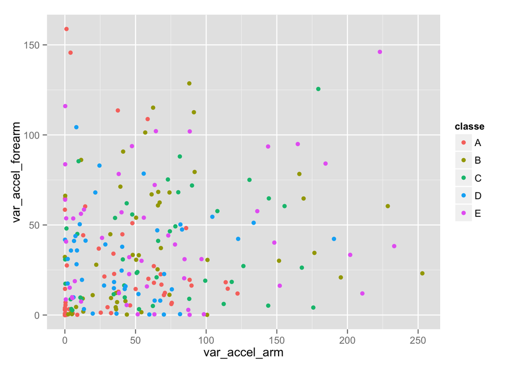

```r
qplot(var_accel_arm, var_accel_forearm, colour = classe, data = training)
```

That plot doesn’t really provide any additional insight into the data. Let’s examine another set of variables.

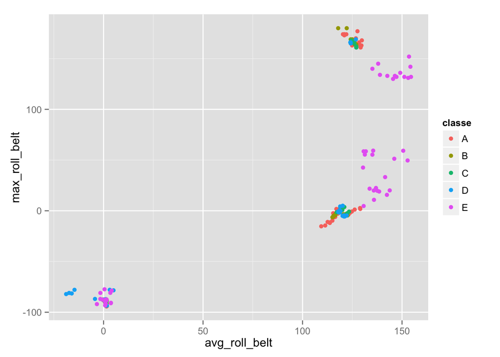

```r
qplot(avg_roll_belt, max_roll_belt, colour = classe, data = training)
```

This plot is a little bit more interesting. The data has distinct clusters and for classe = E, there is a strong corrlection between the average and the max roll in the belt.

Let’s consider one more pair of variables: the variance in the acceleration of the dumbbell and the variance in the roll of the dumbbell.

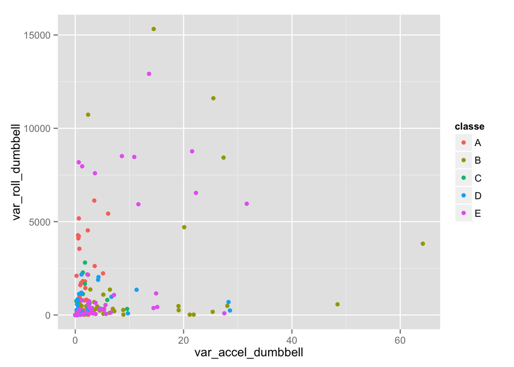

```r
qplot(var_accel_dumbbell, var_roll_dumbbell, colour = classe, data = training)
```

Those two variables create a single cluster with a lot of scatter outside of that cluster. Since we have no real strong predictors, we will want to consider additive models.